# Investigation into Advanced Statistics

Josh Havstad

2024-02-20

# The Need for a New Statistic

## Overview

In this file, I will look into current, popular metrics which are used to evaluate players’ performance. I will try to find if these metrics have flaws or natural biases in them. I will also try to find areas or aspects of basketball that are constantly undervalued or not valued at all. This will allow for a discussion on what the problems are with current metrics and how a new metric can potentially solve this issue.

## Problems with Current Metrics

To support the idea of a need for a new metric, I will investigate the current popular metrics and statistics used to evaluate players. Finding the faults or flaws with these will identify the areas that I need to focus on when creating my new player rating system.

### PER

First, let’s look at the most popular statistic, PER. I am unsure on how teams, coaches, and players view this since I have never been involved in a professional organization, but this metric is referenced the most by the fans and the media when discussing a player’s overall value for a given season.

PER was created by John Hollinger, and it “sums up all a player’s positive accomplishments, subtracts the negative accomplishments, and returns per-minute rating of a player’s performance.” At the time it was created, PER was advanced due to the fact that it adjusted for pace of play and playing time, and it normalized data across seasons so that the average PER is always 15. Some criticisms of this metric, however, are that it overvalues bigs, undervalues defensive impact, and does not incorporate any advanced statistics.

```
## # A tibble: 6 × 29
##   Rk    Player     Pos   Age   Tm    G     MP      PER `TS%` `3PAr` FTr   `ORB%`
##   <chr> <chr>      <chr> <chr> <chr> <chr> <chr> <dbl> <chr> <chr>  <chr> <chr>
## 1 1     Precious … C     23    TOR   55    1140   15.2 .554  .267   .307  9.3
## 2 2     Steven Ad… C     29    MEM   42    1133   17.5 .564  .004   .490  20.1
## 3 3     Bam Adeba… C     25    MIA   75    2598   20.1 .592  .011   .361  8.0
## 4 4     Ochai Agb… SG    22    UTA   59    1209    9.5 .561  .591   .179  3.9
## 5 5     Santi Ald… PF    22    MEM   77    1682   13.9 .591  .507   .274  5.4
## 6 6     Nickeil A… SG    24    TOT   59    884    11.6 .565  .539   .203  1.9
## # ℹ 17 more variables: `DRB%` <chr>, `TRB%` <chr>, `AST%` <chr>, `STL%` <chr>,
## #   `BLK%` <chr>, `TOV%` <chr>, `USG%` <chr>, `` <lgl>, OWS <chr>, DWS <chr>,
## #   WS <chr>, `WS/48` <chr>, `` <lgl>, OBPM <chr>, DBPM <chr>, BPM <chr>,
## #   VORP <chr>
```

```
## # A tibble: 5 × 2
##   Pos    mean
##   <chr> <dbl>
## 1 C      16.1
## 2 PF     13.2
## 3 PG     12.9
## 4 SG     12.2
## 5 SF     11.7
```

We can see from this table that centers and power forwards have the highest average PER values, supporting the idea that this rating favors big men.

```
##
## Call:
## lm(formula = PER ~ Pos, data = advanced)
##
## Residuals:
##     Min      1Q  Median      3Q     Max
## -33.138  -2.865  -0.124   2.885  53.362
##
## Coefficients:
##             Estimate Std. Error t value Pr(>|t|)
## (Intercept)  11.7068     0.5105  22.934  < 2e-16 ***
## PosC          4.3573     0.7141   6.102 1.77e-09 ***
## PosPF         1.4982     0.7396   2.026   0.0432 *
## PosPF-C       1.7932     5.9090   0.303   0.7616
## PosPF-SF      1.7932     5.9090   0.303   0.7616
## PosPG         1.2174     0.7479   1.628   0.1040
## PosPG-SG      4.7932     4.1938   1.143   0.2535
## PosSF-PF     -0.6068     5.9090  -0.103   0.9182
## PosSF-SG      1.9432     4.1938   0.463   0.6433
## PosSG         0.5311     0.6898   0.770   0.4416
## PosSG-PG      0.7432     4.1938   0.177   0.8594
## ---
## Signif. codes:  0 '***' 0.001 '**' 0.01 '*' 0.05 '.' 0.1 ' ' 1
##
## Residual standard error: 5.887 on 668 degrees of freedom
## Multiple R-squared:  0.06548,    Adjusted R-squared:  0.05149
## F-statistic:  4.68 on 10 and 668 DF,  p-value: 1.762e-06
```

```
## Analysis of Variance Table
##
## Response: PER
##            Df Sum Sq Mean Sq F value    Pr(>F)
## Pos        10   1622 162.203  4.6804 1.762e-06 ***
## Residuals 668  23150  34.655
## ---
## Signif. codes:  0 '***' 0.001 '**' 0.01 '*' 0.05 '.' 0.1 ' ' 1
```

In the model above, I set small forward to the reference category since it had the lowest average PER. When running a linear model, we can see that the only two positions with a significant association with PER are Center and Power Forward. The coefficient estimate of Center tells us that we can expect the PER for a Center to be 4.3573 points higher than the PER for a Small Forward, on average.

Additionally, after running an Analysis of Variance, we see that position (p-value = 1.762e-06) is significantly associated to PER. This tells us that there are natural biases within the formulation of PER which are overvaluing certain aspects of basketball while simultaneously undervaluing other aspects of basketball. This is especially true when you consider the overwhelming amount of talent at the guard and wing positions which would make you think that those positions would have higher PER values than they do.

Obviously, nothing can be perfect, but the main flaw with PER is that it lacks the use of advanced statistics in its calculation. It is essentially a weighted combination of “box-score” statistics which every casual fan is familiar with. PER also tends to favor efficient players who do not turn the ball over as much, which in turn favors big men who shoot closer to the basket and typically do not have many ball-handling duties. However, I believe “efficiency” should be relative to a player’s style of play and responsibilities on the floor while playing.

### WS/48

WS/48 is “Win shares per 48 minutes” and is a per-minute version of the popular metric, win shares, which measures a player’s contribution to winning. Winning is the name of the game, and you would expect WS/48 to accurately rank which players are the best or have the most “impact” on success.

```
##                     Player
## 1             Nikola Jokić
## 2         Domantas Sabonis
## 3             Jimmy Butler
## 4              Joel Embiid
## 5  Shai Gilgeous-Alexander
## 6             Jayson Tatum
## 7              Luka Dončić
## 8            Jarrett Allen
## 9              Nic Claxton
## 10           Anthony Davis
## 11          Damian Lillard
## 12        Donovan Mitchell
## 13           Jalen Brunson
## 14            Kevon Looney
## 15   Giannis Antetokounmpo
## 16           DeMar DeRozan
## 17             Evan Mobley
## 18            James Harden
## 19          Nikola Vučević
## 20         Lauri Markkanen
## 21           Julius Randle
## 22             Brook Lopez
## 23           Mason Plumlee
## 24           Pascal Siakam
## 25             Rudy Gobert
```

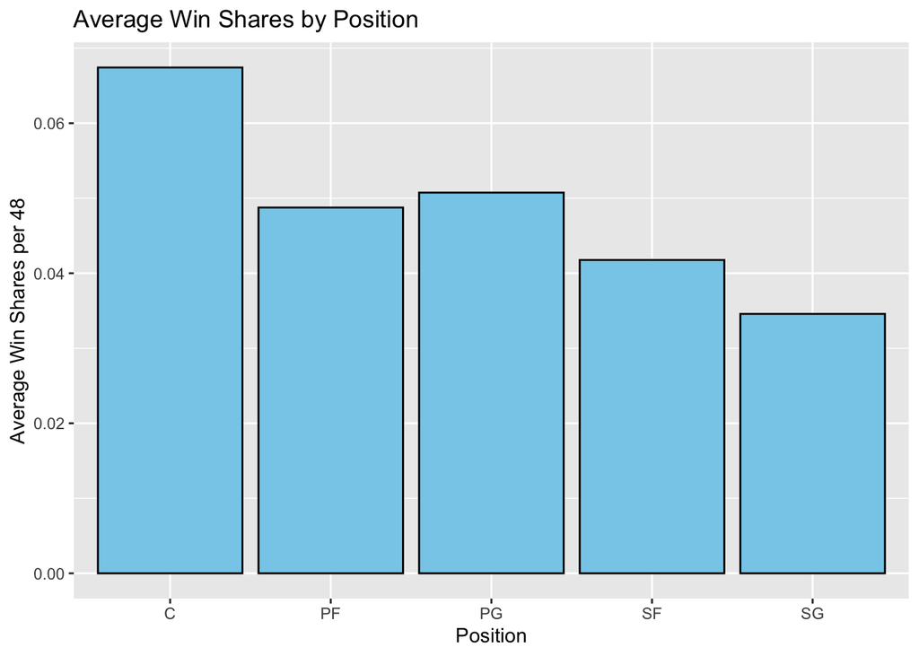

```
##
## Call:
## lm(formula = WS/48 ~ Pos, data = NBA23)
##
## Residuals:
##      Min       1Q   Median       3Q      Max
## -0.07575 -0.03922 -0.01375  0.02633  0.24300
##
## Coefficients:
##               Estimate Std. Error t value Pr(>|t|)
## (Intercept)  0.0345833  0.0047177   7.330 8.66e-13 ***
## PosC         0.0328356  0.0069295   4.739 2.77e-06 ***
## PosPF        0.0141708  0.0070380   2.013   0.0446 *
## PosPF-C      0.0008333  0.0529565   0.016   0.9875
## PosPF-SF    -0.0095833  0.0529565  -0.181   0.8565
## PosPG        0.0161639  0.0072455   2.231   0.0261 *
## PosPG-SG     0.0622917  0.0375942   1.657   0.0981 .
## PosSF        0.0071845  0.0070191   1.024   0.3065
## PosSF-PF    -0.0200000  0.0529565  -0.378   0.7058
## PosSF-SG     0.0654167  0.0375942   1.740   0.0824 .
## PosSG-PG     0.0622917  0.0375942   1.657   0.0981 .
## ---
## Signif. codes:  0 '***' 0.001 '**' 0.01 '*' 0.05 '.' 0.1 ' ' 1
##
## Residual standard error: 0.05275 on 528 degrees of freedom
##   (1 observation deleted due to missingness)
## Multiple R-squared:  0.05442,    Adjusted R-squared:  0.03651
## F-statistic: 3.038 on 10 and 528 DF,  p-value: 0.0009358
```

```
## Analysis of Variance Table
##
## Response: WS/48
##            Df  Sum Sq   Mean Sq F value    Pr(>F)
## Pos        10 0.08453 0.0084535  3.0385 0.0009358 ***
## Residuals 528 1.46897 0.0027821
## ---
## Signif. codes:  0 '***' 0.001 '**' 0.01 '*' 0.05 '.' 0.1 ' ' 1
```

### VORP

VORP is another popular advanced metric which stands for Value Over Replacement Player. As it says in the title, this statistic is meant to quantify a player’s impact on their team compared to a hypothetical “replacement-level” player. A “replacement-level” player is essentially a player that is readily available and could be signed for a minimum-salary. VORP is calculated with various box-score statistics as well. Teams should aim for all their players to be better than some hypothetical minimum-salary player if they want to be competitive and successful. VORP values can be both positive and negative, with larger values indicating that a player contributes more to their team.

```
##                     Player VORP
## 1             Nikola Jokić  8.8
## 2              Luka Dončić  6.6
## 3              Joel Embiid  6.4
## 4             Jimmy Butler  5.8
## 5  Shai Gilgeous-Alexander  5.6
## 6         Domantas Sabonis  5.4
## 7    Giannis Antetokounmpo  5.4
## 8             Jayson Tatum  5.1
## 9         Donovan Mitchell  5.0
## 10          Damian Lillard  4.9
## 11           Stephen Curry  4.7
## 12       Tyrese Haliburton  4.4
## 13           Anthony Davis  4.0
## 14            James Harden  4.0
## 15            LeBron James  4.0
## 16           Julius Randle  3.9
## 17            Kevin Durant  3.9
## 18               Ja Morant  3.8
## 19           Jalen Brunson  3.5
## 20           Kawhi Leonard  3.5
```

Looking at the best rated players in VORP, we see that Nikola Jokic, Luka Doncic, and Joel Embiid are the only players over 6. Jokic clearly comes out on top with 8.8. These results make sense, as these players had some of the best seasons statistically speaking, and their teams would not be nearly as successful without them.

```
##              Player VORP
## 1    Andrew Wiggins  0.5
## 2   Anfernee Simons  0.5
## 3        Cedi Osman  0.5
## 4        Coby White  0.5
## 5    Grant Williams  0.5
## 6   Jaden McDaniels  0.5
## 7       Jalen Duren  0.5
## 8  Keita Bates-Diop  0.5
## 9      Marcus Smart  0.5
## 10         Mo Bamba  0.5
## 11    Royce O'Neale  0.5
## 12        Tre Jones  0.5
## 13   Troy Brown Jr.  0.5
## 14       AJ Griffin  0.4
## 15          Bol Bol  0.4
## 16     Caleb Martin  0.4
## 17      Gary Harris  0.4
## 18    Javonte Green  0.4
## 19     John Collins  0.4
## 20    Mark Williams  0.4
```

Looking at the players that finished the season with below-average VORP, we find surprising players such as Jaden McDaniels and Marcus Smart. I say this is surprising due to the fact that these players were instrumental in their teams’ success during the 2022-2023 NBA season, as Marcus Smart started for the Boston Celtics who made the Conference Finals, and Jaden McDaniels was big in helping the Timberwolves making the playoffs. These players also served as the primary defenders against many of the top scoring talents in the league, and their team’s success would often come down to if they were successful in slowing down the primary scorer on the other team.

```
##            Player Pos      PTS   FG%      TRB      AST       STL       BLK
## 1 Jaden McDaniels  SF 12.06329 0.517 3.886076 1.873418 0.9367089 0.9620253
## 2    Marcus Smart  PG 11.52459 0.415 3.131148 6.262295 1.5245902 0.3770492
##        TOV       MP
## 1 1.417722 30.58228
## 2 2.344262 32.08197
```

From the table above with the box-score statistics, we see that these players were not huge contributors in counting stats despite all averaging over 30 minutes a night, with none of the players averaging more than 13 points or 4 rebounds. This could explain their low VORP rating, as the statistic factors in these statistics.

```
##                      Player VORP
## 1           Devonte' Graham  0.6
## 2               Ivica Zubac  0.6
## 3             Jalen Johnson  0.6
## 4              Jevon Carter  0.6
## 5               Josh Okogie  0.6
## 6  Kentavious Caldwell-Pope  0.6
## 7           Khris Middleton  0.6
## 8                 Kris Dunn  0.6
## 9               Luke Kornet  0.6
## 10             Zach Collins  0.6
## 11              Ben Simmons  0.7
## 12            Chris Boucher  0.7
## 13            Devin Vassell  0.7
## 14          Harrison Barnes  0.7
## 15              Isaac Okoro  0.7
## 16       Isaiah Hartenstein  0.7
## 17             Jusuf Nurkić  0.7
## 18                KJ Martin  0.7
## 19            Moritz Wagner  0.7
## 20         Robert Covington  0.7
```

On the flip side, we can see players who finished slightly above-average in VORP (and better than Jaden McDaniels and Marcus Smart) in the table above. Some players I found surprising were Robert Covington, Devonte’ Graham, Luke Kornet, and Ben Simmons. This is not meant to diminish these players, but I would not consider any of those players more impactful or better than the two players I previously looked into that were below-average in VORP. These four players who were above-average in VORP struggled to find consistent minutes on the teams they played for because they simply are not as talented as some of their counterparts in the NBA.

```
##             Player Pos      PTS   FG%      TRB       AST       STL       BLK
## 1      Ben Simmons  PG 6.928571 0.566 6.261905 6.0952381 1.2857143 0.5714286
## 2  Devonte' Graham  PG 7.383562 0.374 1.671233 2.6849315 0.6164384 0.2191781
## 3      Luke Kornet   C 3.782609 0.665 2.855072 0.7681159 0.1594203 0.6666667
## 4 Robert Covington  PF 6.000000 0.445 3.458333 1.1875000 0.7916667 0.6875000
##         TOV       MP
## 1 2.3095238 26.30952
## 2 0.7260274 18.32877
## 3 0.3623188 11.65217
## 4 0.6666667 16.22917
```

Looking at the box-score stats for these 4 players, we can see that they tended to average worse stats than McDaniels and Smart, yet they rated better than them. The main difference between these 4 players and the previous 2 players I named is the disparity in the minutes played per game. In my mind, players who could be replaced by a replacement level player are those that struggle to find consistent minutes or roles on their team.

```
## # A tibble: 5 × 2
##   Pos    mean
##   <fct> <dbl>
## 1 PG    0.825
## 2 C     0.801
## 3 PF    0.554
## 4 SF    0.328
## 5 SG    0.283
```

```
##
## Call:
## lm(formula = VORP ~ Pos, data = NBA23)
##
## Residuals:
##     Min      1Q  Median      3Q     Max
## -1.8250 -0.7250 -0.3282  0.2870  7.9991
##
## Coefficients:
##             Estimate Std. Error t value Pr(>|t|)
## (Intercept)  0.28320    0.10764   2.631  0.00877 **
## PosC         0.51773    0.15811   3.274  0.00113 **
## PosPF        0.27072    0.16058   1.686  0.09242 .
## PosPF-C     -0.18320    1.20831  -0.152  0.87955
## PosPF-SF    -0.28320    1.20831  -0.234  0.81478
## PosPG        0.54180    0.16532   3.277  0.00112 **
## PosPG-SG     1.51680    0.85779   1.768  0.07759 .
## PosSF        0.04496    0.16016   0.281  0.77905
## PosSF-PF    -0.68320    1.20831  -0.565  0.57203
## PosSF-SG     1.31680    0.85779   1.535  0.12535
## PosSG-PG     0.76680    0.85779   0.894  0.37177
## ---
## Signif. codes:  0 '***' 0.001 '**' 0.01 '*' 0.05 '.' 0.1 ' ' 1
##
## Residual standard error: 1.204 on 528 degrees of freedom
##   (1 observation deleted due to missingness)
## Multiple R-squared:  0.04372,    Adjusted R-squared:  0.02561
## F-statistic: 2.414 on 10 and 528 DF,  p-value: 0.008202
```

```
## Analysis of Variance Table
##
## Response: VORP
##            Df Sum Sq Mean Sq F value   Pr(>F)
## Pos        10  34.96  3.4963  2.4139 0.008202 **
## Residuals 528 764.76  1.4484
## ---
## Signif. codes:  0 '***' 0.001 '**' 0.01 '*' 0.05 '.' 0.1 ' ' 1
```

## What does this tell us?

After looking into a few of the most popular “advanced” metrics that are used to evaluate a player’s performance, value, and contribution, we can see that there may be some flaws with the current metrics. First off, each metric seemed to have some biases towards favoring bigs, especially centers. This could be due to the fact that the metrics put more importance on areas of basketball that centers normally thrive at, including rebounding, efficiency, low turnovers, etc. It has become clear that the superstar players will be near the top of each metric regardless of position because they put up great counting stats, but it is the non-star players I am interested in. Because bigs tend to have better metrics on average, this most likely occurs because the non-star centers are being rated better than the non-star wings and guards. We have also seen that counting stats (points, rebounds, assists, blocks, steals, turnovers) have a large impact on how players are rated, but this does not always tell the full story. Some players may be at a natural advantage to acquire these stats due to the role they play or position they are put in, but it does not make them inherently better or more valuable to their team.

Now, maybe centers are simply more important to basketball and the NBA is overflowing with talent at the position. However, as an avid NBA fan, I know that wings and perimeter players tend to be more coveted than bigs when it comes to free agency, trades, draft picks, and the buyout market. Every team is always looking for another versatile wing that can shoot, handle, play defense, etc. Additionally, a lot of teams prefer to go small-ball and they have players playing out of their normal position. Yet, shooting guards and small forwards consistently performed bad, on average, in the metrics we have investigated. I think one reason for this is due to how lineups are set and positions are identified now. Players like LeBron James and Kevin Durant are now considered power forwards even though they primarily played small forward for most of their career. Jimmy Butler, who was once primarily a shooting guard and small forward, is listed as a power forward.

Positions have become almost irrelevant, and due to the advanced skill sets of players in today’s NBA, many players could realistically play multiple positions with ease. To show how positional distinctions do not tell us much about players, we can look at which stats are associated with each position.

## Which statistics are associated with each position?

I will use anova to identify which of the variables in the NBA data set are most closely associated to each position in basketball. If there are many similarities between positions, this could support the idea that position lines are blurred and they do not hold much value or tell us much about players anymore.

```
## Point Guard
```

```
##        Variable      P_Value
## AST%       AST% 7.747920e-48
## 2ast       2ast 4.650196e-37
## 3ast       3ast 7.947699e-25
## AST         AST 2.813141e-16
## TRB%       TRB% 4.283176e-13
## %Dunks   %Dunks 2.400906e-10
## DRB%       DRB% 3.667676e-10
## ORB%       ORB% 4.897466e-10
## %C3         %C3 3.050270e-09
## %0-3       %0-3 3.386337e-08
## 2P%         2P% 1.325598e-07
## #Dunks   #Dunks 3.586277e-07
## FG%         FG% 4.162195e-06
## ORB         ORB 5.035289e-06
## eFG%       eFG% 6.980461e-06
## %10-16   %10-16 1.147097e-05
## 0-3%       0-3% 3.457606e-05
## TS%         TS% 5.174902e-05
## BLK%       BLK% 1.808228e-04
## TOV         TOV 3.668886e-04
## %16-3P   %16-3P 4.409950e-04
## BLK         BLK 5.005996e-04
## Dist.     Dist. 7.347412e-04
## USG%       USG% 7.993616e-04
## STL         STL 9.494705e-04
## TRB         TRB 1.500561e-03
## TOV%       TOV% 4.838488e-03
## DRB         DRB 1.331956e-02
## VORP       VORP 1.756852e-02
## STL%       STL% 2.080170e-02
## 3PA         3PA 3.214137e-02
## 3P           3P 4.920041e-02
```

The variables most significantly associated with the point guard position are assist percentage, percentage of their made 2 and 3 pointers which were assisted, number of assists, and total rebound percentage.

```
## Shooting Guard
```

```
##        Variable      P_Value
## TRB%       TRB% 8.907826e-13
## ORB%       ORB% 1.950614e-11
## DRB%       DRB% 6.184682e-09
## ORB         ORB 2.428879e-08
## Dist.     Dist. 5.385346e-08
## %0-3       %0-3 7.032799e-07
## %2P         %2P 9.676538e-07
## %3P         %3P 9.691659e-07
## %Dunks   %Dunks 9.861080e-07
## BLK         BLK 1.330580e-06
## TRB         TRB 2.296299e-06
## #Dunks   #Dunks 1.113145e-05
## FG%         FG% 1.947930e-05
## DRB         DRB 3.509137e-05
## Age         Age 1.310612e-04
## WS/48     WS/48 1.604860e-04
## 2ast       2ast 3.637186e-04
## WS           WS 8.170739e-04
## FT%         FT% 9.523142e-04
## %3-10     %3-10 1.700528e-03
## OWS         OWS 1.900045e-03
## 2P%         2P% 1.958409e-03
## DWS         DWS 2.002833e-03
## 3ast       3ast 3.056849e-03
## VORP       VORP 5.066174e-03
## 3P           3P 5.501449e-03
## 3PA         3PA 9.571469e-03
## PER         PER 9.651499e-03
## USG%       USG% 1.071073e-02
## PF           PF 1.113508e-02
## eFG%       eFG% 1.318098e-02
## BLK%       BLK% 2.307911e-02
## 0-3%       0-3% 3.157396e-02
## STL%       STL% 4.158089e-02
```

The variables most significantly associated with the shooting guard position have to do with rebounding percentages, block percentage, 2 point percentage, and win shares.

```
## Small Forward
```

```
##        Variable      P_Value
## %3-10     %3-10 4.636514e-07
## %2P         %2P 5.372543e-07
## %3P         %3P 5.380076e-07
## Dist.     Dist. 2.711971e-06
## TOV%       TOV% 1.902500e-04
## AST%       AST% 2.333885e-04
## %0-3       %0-3 1.668629e-03
## 3ast       3ast 2.186971e-03
## TRB%       TRB% 2.526490e-03
## BLK%       BLK% 2.582133e-03
## 2ast       2ast 3.138729e-03
## ORB%       ORB% 3.916082e-03
## %Dunks   %Dunks 4.905494e-03
## FG%         FG% 5.836996e-03
## 3P           3P 8.454901e-03
## 3PA         3PA 9.410035e-03
## 3-10%     3-10% 9.471633e-03
## PER         PER 1.302812e-02
## DRB%       DRB% 1.367944e-02
## BLK         BLK 1.508616e-02
## %C3         %C3 1.561616e-02
## FTr         FTr 1.566149e-02
## C3%         C3% 3.161143e-02
## ORB         ORB 3.220600e-02
## AST         AST 3.858756e-02
## VORP       VORP 3.952117e-02
```

The variables most associated with the small forward position have to do with shot distances, assist percentage, turnover percentage, and percent of 2 point field goals assisted.

```
## Power Forward
```

```
##        Variable      P_Value
## 3ast       3ast 7.732508e-06
## 2ast       2ast 7.217464e-05
## %C3         %C3 5.512048e-04
## AST%       AST% 5.995682e-04
## 2P%         2P% 1.632327e-03
## DRB%       DRB% 1.051439e-02
## %10-16   %10-16 1.084443e-02
## %16-3P   %16-3P 1.418199e-02
## TRB%       TRB% 1.775733e-02
## 0-3%       0-3% 2.017080e-02
## #Dunks   #Dunks 3.121398e-02
```

The variables most significantly associated with the power forward position are rebounding percentages, percent of made shots that are assisted, dunks, and 2 point field goal percentage.

```
## Center
```

```
##        Variable      P_Value
## TRB%       TRB% 1.221515e-65
## ORB%       ORB% 2.062403e-61
## %Dunks   %Dunks 7.687860e-49
## Dist.     Dist. 1.879555e-45
## %0-3       %0-3 4.191086e-44
## DRB%       DRB% 2.015275e-38
## %2P         %2P 5.080967e-35
## %3P         %3P 5.091219e-35
## ORB         ORB 1.765112e-29
## FG%         FG% 2.234071e-28
## BLK         BLK 1.132057e-23
## BLK%       BLK% 3.898947e-21
## #Dunks   #Dunks 3.663462e-19
## 2ast       2ast 6.282160e-17
## 3PA         3PA 4.137027e-13
## TRB         TRB 5.893003e-13
## 3P           3P 2.213739e-12
## WS/48     WS/48 4.762588e-12
## eFG%       eFG% 8.631308e-12
## TS%         TS% 2.681547e-10
## %3-10     %3-10 2.831606e-10
## FTr         FTr 3.165480e-10
## 2P%         2P% 6.469176e-10
## PER         PER 1.672094e-09
## 3ast       3ast 3.074757e-09
## AST%       AST% 5.356005e-09
## DRB         DRB 9.132085e-08
## FT%         FT% 9.837183e-07
## OWS         OWS 1.580917e-05
## C3%         C3% 2.302879e-05
## WS           WS 4.313213e-05
## 0-3%       0-3% 7.345819e-05
## AST         AST 4.306293e-04
## %16-3P   %16-3P 6.034362e-04
## 3P%         3P% 8.583329e-04
## PF           PF 9.172527e-04
## 3-10%     3-10% 9.496031e-04
## STL         STL 3.279756e-03
## DWS         DWS 4.305665e-03
## STL%       STL% 5.552169e-03
## USG%       USG% 8.369893e-03
## DBPM       DBPM 1.208751e-02
## FGA         FGA 1.267199e-02
## VORP       VORP 1.682786e-02
## 2P           2P 1.688682e-02
## BPM         BPM 3.568393e-02
## TOV%       TOV% 4.195225e-02
```

Similar to the power forward position, the variables most significantly associated with the center position are rebounding percentages and dunks. Other important variables are block percentage, field goal percentage, and shot distance.

### Positional Similarities

```
##     PG_SG  SG_SF SF_PF   PF_C
## 1    2ast   TRB%  AST%   3ast
## 2    3ast   ORB%  3ast   2ast
## 3    TRB%   DRB%  TRB%   AST%
## 4  %Dunks    ORB  2ast    2P%
## 5    DRB%  Dist.  DRB%   DRB%
## 6    ORB%   %0-3   %C3 %16-3P
## 7    %0-3    %2P  <NA>   TRB%
## 8     2P%    %3P  <NA>   0-3%
## 9  #Dunks %Dunks  <NA> #Dunks
## 10    FG%    BLK  <NA>   <NA>
## 11    ORB    FG%  <NA>   <NA>
## 12   eFG%   2ast  <NA>   <NA>
## 13   0-3%  %3-10  <NA>   <NA>
## 14   BLK%   3ast  <NA>   <NA>
## 15    BLK   VORP  <NA>   <NA>
## 16  Dist.     3P  <NA>   <NA>
## 17   USG%    3PA  <NA>   <NA>
## 18    TRB    PER  <NA>   <NA>
## 19    DRB   BLK%  <NA>   <NA>
## 20   VORP   <NA>  <NA>   <NA>
## 21   STL%   <NA>  <NA>   <NA>
## 22    3PA   <NA>  <NA>   <NA>
## 23     3P   <NA>  <NA>   <NA>
```

We can see from the table above that each one position difference (point guard to shooting guard, shooting guard to small forward, etc.) share many similarities in terms of stats that are significantly associated with the positions. This shows how many positions most likely contribute in similar ways on the court and have similar responsibilities. Obviously, we do not have much in-depth knowledge of the associations between the stats and positions, but from this output and knowledge of basketball, it is clear that positional distinctions and duties are not as clear-cut as they used to be.

## My Proposed Solution

From this investigation, I have learned many things about the various statistics used in basketball:

1. Many “advanced” statistics seem to favor bigs, especially centers, which consequentially undervalues wing players. This could indicate that things such as rebounding or low turnovers are being overvalued in the formulation of these statistics.
2. Most of the statistics found in basketball aim to evaluate a player’s overall impact by including stats from all aspects of basketball, however, many players are given roles which only enable them to succeed in certain aspects of the game. This leads to certain players who are elite at one or two things being rated lower than players that they are actually more impactful then.
3. Positions no longer mean much in today’s NBA, as players have very versatile skillsets which allow them to technically play multiple positions. This leads to players being listed out of their normal positions.

This has led to the overarching question — how can a player’s true contribution and value to his team be rated accordingly, when accounting for his designated role and responsibility?

My proposed solution is to create a statistic which rates players based on their responsibilities and what they excel at. I will not aim to evaluate players’ with every statistic like PER does, but instead, I will evaluate players based on their play-style (or archetype as I will call it). This means that my formula for my new metric may be different depending on a player’s archetype. I want to be able to rate and rank the best players at 3&D, screening and rolling, and slashing, for example. The reasoning for this is because I think that instead of filling rosters with positions, teams prefer to get players which fulfill certain team needs, often regardless of position. Similar to PER, I want my statistic to be normalized so that one value always represents the average value across the league. This would allow for a comparison of players between different seasons. There will be other things to consider, such as choosing how many play-styles/archetypes to include and how to go about creating the equations to rate each play-style.

This will be explored in my future file(s) which will be located in this same GitHub repository.